# HW6

## 0. Training the model

Let's train a XGBoost model on the Magic Telescope dataset. The dataset contains information about the energy of gamma particles hitting the telescope. The task is to classify the particles into two classes: gamma and hadron. The dataset is available [here](https://archive.ics.uci.edu/ml/datasets/magic+gamma+telescope).

```
XGBClassifier(base_score=None, booster=None, callbacks=None,
              colsample_bylevel=None, colsample_bynode=None,
              colsample_bytree=None, device=None, early_stopping_rounds=None,
              enable_categorical=False, eval_metric=None, feature_types=None,
              gamma=None, grow_policy=None, importance_type=None,
              interaction_constraints=None, learning_rate=None, max_bin=None,
              max_cat_threshold=None, max_cat_to_onehot=None,
              max_delta_step=None, max_depth=None, max_leaves=None,
              min_child_weight=None, missing=nan, monotone_constraints=None,
              multi_strategy=None, n_estimators=None, n_jobs=None,
              num_parallel_tree=None, random_state=None, ...)
```

```
Accuracy: 0.8772344900105152
```

## 1. Permutation-based variable importance

I used the log loss function as the loss function.

I calculated the same ratio using dx.Explainer for comparison. The results are very similar.

[output not shown]

|  | my method | dalex |
| --- | --- | --- |
| fLength: | 2.019370 | 2.070727 |
| fWidth: | 2.599897 | 2.541839 |
| fSize: | 2.718364 | 2.748674 |
| fConc: | 2.966903 | 2.950063 |
| fConc1: | 1.896760 | 1.839500 |
| fAsym: | 1.103452 | 1.092350 |
| fM3Long: | 1.447897 | 1.428772 |
| fM3Trans: | 1.079132 | 1.099212 |
| fAlpha: | 2.585761 | 2.679840 |
| fDist: | 1.154163 | 1.171785 |

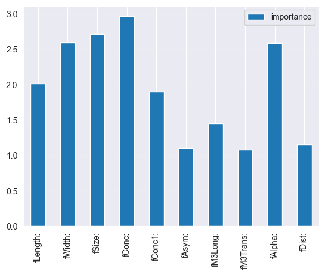

## 2. Permutation-based variable importance for other models

I thought it would be interesting to see how the permutation-based variable importance method works for other models. I chose:

- XGBoost with features transformed using PCA
  - While it makes it difficult to attribute importance to original features, I thought it would be interesting to see how the method works for features transformed using PCA. It addresses the problem of correlated features, as PCA features are orthogonal.
- Support Vector Machine (produces only class predictions, not probabilities - not suitable for log loss)
- Random Forest that has been purposely underfitted
- MLP that has been purposely overfitted
  - It should be interesting to see how the method works for overfitted and underfitted models.

### XGBoost with PCA

```
PCA()
```

```
XGBClassifier(base_score=None, booster=None, callbacks=None,
              colsample_bylevel=None, colsample_bynode=None,
              colsample_bytree=None, device=None, early_stopping_rounds=None,
              enable_categorical=False, eval_metric=None, feature_types=None,
              gamma=None, grow_policy=None, importance_type=None,
              interaction_constraints=None, learning_rate=None, max_bin=None,
              max_cat_threshold=None, max_cat_to_onehot=None,
              max_delta_step=None, max_depth=None, max_leaves=None,
              min_child_weight=None, missing=nan, monotone_constraints=None,
              multi_strategy=None, n_estimators=None, n_jobs=None,
              num_parallel_tree=None, random_state=None, ...)
```

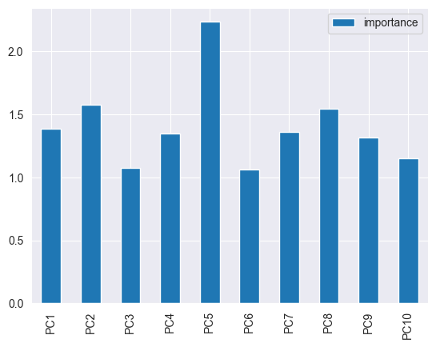

What I found interesting is that I expected the first principal component to be the most important, but it's not.

### Underfitted Random Forest

Random forests have been limited to a depth of 2. This should make the model underfitted.

```
RandomForestClassifier(max_depth=2)
```

```
Accuracy: 0.7518401682439537
```

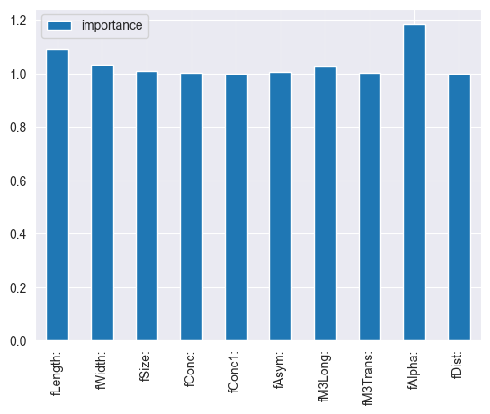

As should be expected, the variable importance plot is close to 1. That's because the model is bad at classification both with and without the permutation of the feature, so $L_{nocol} \approx L_{overall}$ and the ratio $L_{nocol}/L_{overall}$ is close to 1.

### Overfitted MLP

```
Accuracy: 0.8480546792849631
```

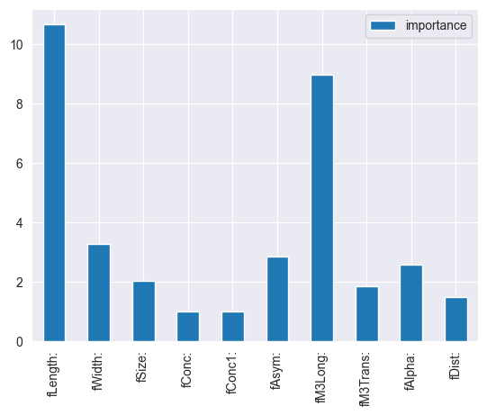

Overfitted MLP on the other hand (compared to underfitted RF) has importances that vary widely between features and are completely different from the original model. This is because the overfitted model is very sensitive to data out-of-distribution, so the permutation of the feature has a big impact on the loss function value (and not neccessarily reflecting the real importance, but just noise).

## 3. Comparison of variable importance methods for the original model

In the comparison below the following metrics are used:

- Tree-specific metrics from XGBoost:
  - weight
  - gain
  - cover
  - total_gain
  - total_cover
- absolute value of mean SHAP values
- permutation-based variable importance

The importances have been normalized to the range [0, 1] for each method separately.

The following plot presents "total importance" for each feature, which is the sum of importances from all methods. Each colored box represents the "contribution" to the total of a different method.

[interactive chart not shown]

We can also see how much the method used affects the ranking of features. The following plot presents the rank of each feature for each method - 1 is the most important feature, 10 is the least important feature.

[interactive chart not shown]

Despite the fact that the ranks vary widely, a few features are consistently important/unimportant across all methods:

- fWidth - important
- fLength - important
- fAsym - unimportant

Also, for some reason the "cover" metric has an especially different ranking than the other methods, for example assigning a lot of importance to fConc1, despite it being unimportant for other methods.